# Examining Time-Averaged Annual Uncertainty

Sebastian T. Rowland

8/23/2021

# **Set Up**

## Problem Context

Broadly, characterizing where we have greater uncertainty in our estimates of PM<sub>2.5</sub> concentration can help inform subsequent model development and monitor placement. Our model, the CONUS-BNE, combines several state-of-the-art PM<sub>2.5</sub> models; therefore its estimates should reflect the combined strengths of these models, and its uncertainty should reflect both uncertainty in how to combine the models, disagreement among the models, lack of data, and fundamental uncertainty (aleatoric uncertainty). It is important to note that a model’s uncertainty always depends on the particular features of that model.

There are two components of the uncertainty analysis: 1) qualitatively describing where uncertainty is the highest, including any clusters and 2) quantitatively assessing the relationship between uncertainty and *a priori*-selected potential explanatory factors.

For now we will examine results from the CONUS-BNE annual model because the daily model is not yet finalized. The model found very similar spatial patterns of uncertainty year to year; therefore we decided to average the years together into a single spatial dataset.

## Set Up Data

We will first bring in the data I prepared in previous steps. This data includes PM<sub>2.5</sub> estimates and uncertainty from BNE, and the potential explanatory variables. The potential explanatory variables were conbined with the BNE estimates via nearest neighbors. We will then average the values across years. We will pull in the already-prepared data, for which we joined BNE estimates and potential explanatory variables via nearest-neighbors. We then average the values across years, since the spatial patterns of uncertainty and the potential explanatory variables are quite consistent across the years.

# **Initial Data Exploration**

Let’s then take a look at the distribution of predictive uncertainty.

- We have a long right tail - there are locations with extremely high uncertainty, but not so much for low uncertainty.

```
## [1] "Distribution of Predictive Uncertainty"
```

```
##     mean   sd  min   Q1 median   Q3  max
## 25% 0.77 0.33 0.26 0.52   0.69 0.96 2.38
```

## Crude Correlations

Let’s look at the linear correlations among the explanatory variables, and with predictive uncertainty (pred_sd).

- Predicted PM<sub>2.5</sub> concentration (pred_mean, the mean of the posterior predictive distribution of the CONUS-BNE model) was negatively correlated with predictive uncertainty
- Predictive uncertainty was highly correlated with distance to the nearest monitor (mon_dist1), but not strongly correlated with any other potential explanatory variable.
- However, these linear correlations may be masking non-linear relationships.
- It is also interesting to note that predicted concentration is negatively correlated with distance to nearest monitor and elevation.

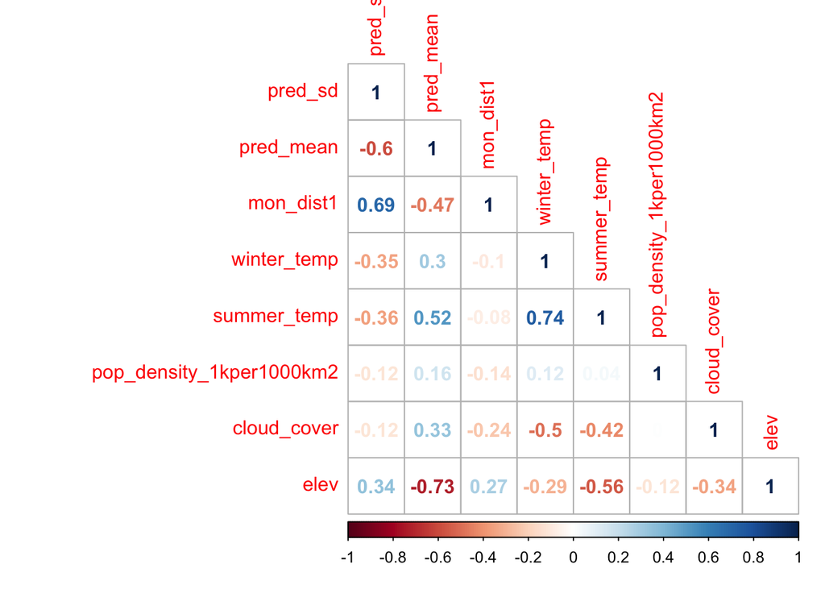

Next, let’s consider alternative metrics of monitor proximity by plotting the correlation between distance to nearest monitor and predictive uncertainty.

- The correlation between predictive uncertainty and distance to nearest monitor increases as we consider further away monitors (e.g., mon_dist2 is the distance to the second-nearest monitor).
- This correlation plateaus after the fourth-nearest monitor.
- One part of the explanation for this phenonenon is that the distance to the fourth-nearest monitor actually provides some information about the nearest monitor and second and third-nearest monitors. Specifically, the distance to the fourth-nearest monitor tells us the maximum possible distance of the 3 more-proximate monitors. For example, if the distance to the fourth-nearest monitor is 10 km, then the nearest monitor must also be within 10 km of the point.
- Additionally, low distance to fourth-nearest monitor indicates high monitor density.
- These distances are highly correlated to each other (e.g., the correlation between distance to nearest monitor and second-nearest monitor is 0.89), so for now if we use distance to nearest monitor we will not lose much information.

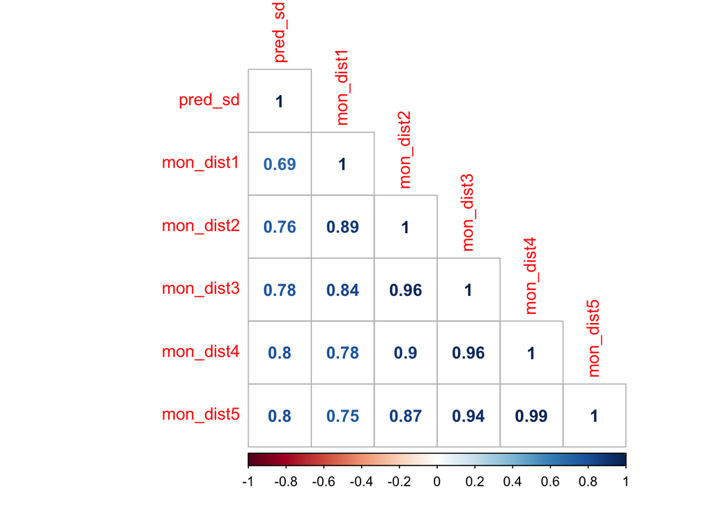

# **Model Development**

## Check For Linearity

Next let’s fit a model with just one monitor-proximity metric, distance to nearest monitor, and then check for evidence of non-linear terms with penalized splines.

- We see that population density has an estimated degree of freedom of 1, so we can model it as a linear term.
- All other terms have edf >> 1, so we will model those as penalized splines

```
##                s(pred_mean)                s(mon_dist1)
##                    8.415391                    7.903246
##              s(winter_temp)              s(summer_temp)
##                    8.801128                    8.361118
## s(pop_density_1kper1000km2)              s(cloud_cover)
##                    1.000000                    8.892225
##                     s(elev)
##                    7.857960
```

## Fit Non-Spatial Model

We will first examine the relationship between the potential explanatory variables and uncertainty via simple GAMs that do not take into account the spatial structure of the data. We fit univariate models to examine the non-linear relationships between the potential explanatory factors and a multivariate GAM to examine the proportion of uncertainty explained by each variable.

- We see that the distance to nearest monitor has positively monotonic relationship with predictive uncertainty, with a steeper slope above 300 km (where data is more sparse).

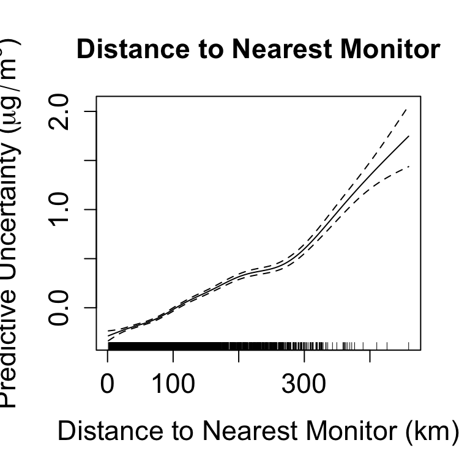

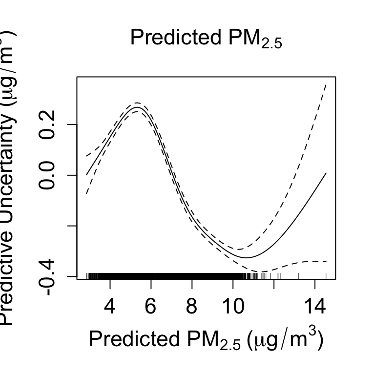

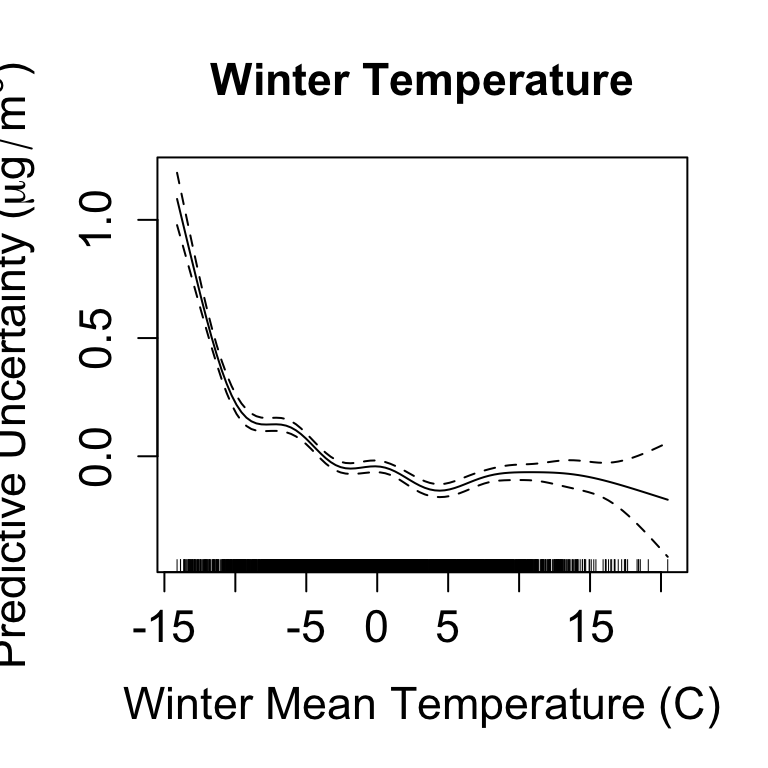

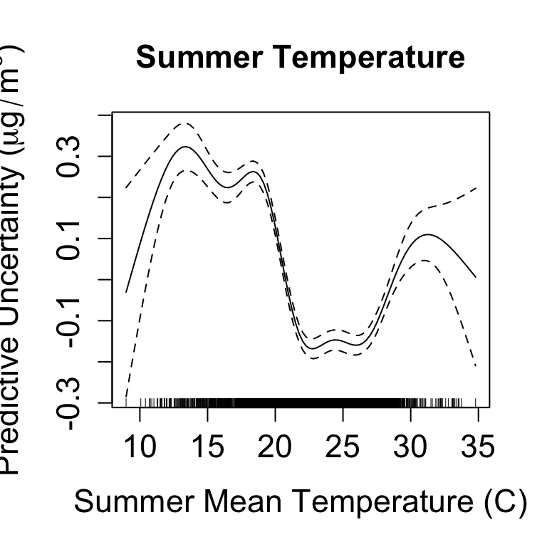

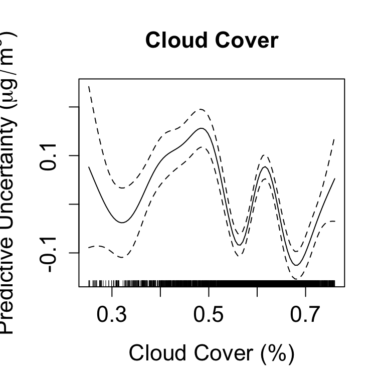

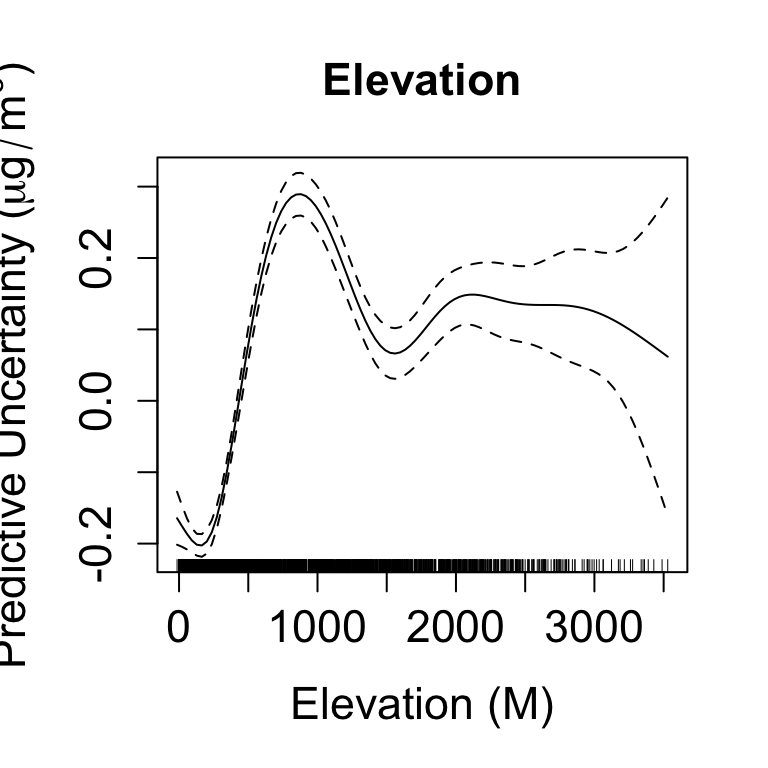

```
##           var prop_dev
## 1   pred_mean    0.426
## 2    mon_dist    0.219
## 3 winter_temp    0.108
## 4 summer_temp    0.087
## 5 pop_density    0.057
## 6       cloud    0.031
## 7        elev    0.001
```

## Examine Residuals

So far, so good. However, our residuals may be correlated across space, violating the model’s assumption that the residuals are independently and identically distributed (i.i.d). Let’s check for spatial autocorrelation with Moran’s i and a semi-variogram

- There is statistically significant spatial correlation of the residuals, though the magnitude of the correlation is low.
- Our model’s residuals have much lower spatial correlation than unadjusted uncertainty, indicating that our model captures many of the underlying spatial processes generating predictive uncertainty.

```
## [1] "Moran's I: 0.04863  SD: 0.00065  p value:0"
```

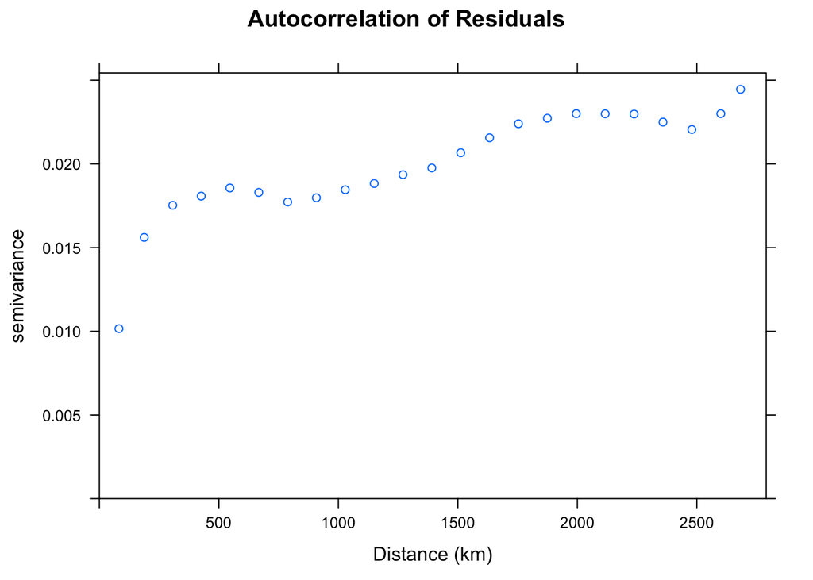

```
## [1] "Moran's I: 0.24604  SD: 0.00065  p value:0"
```

## Initial Spatial Model: Geoadditive Model

And so what we find is that we need a lot of knots to get rid of the significant autocorrelation

I do also wonder if this auto corr is so small that we can just like… ignore it?

### Geoadditive Model with Default Knots

The default number of knots for a tensor product is 5 knots per basis, for a total of 5*5 = 25 maximum degrees of freedom.

```
## [1] "Moran's I: 0.0263  SD: 0.00065  p value:0"
```

### Geoadditive Model with Minimal Sufficient Knots

After iterating over several possible number of knots, I found that 18 knots per basis was the sufficient number of knots to get rid of the spatial correlation of the residuals.

- This tensor product has 229 estimated degrees of freedom.

```
## [1] "Moran's I: 0.00042  SD: 0.00064  p value:0.237"
```

However, the relationship between distance to nearest monitor and predictive uncertainty has been obliterated.

- This result indicates that a geoadditive model is not a good approach for this data.

```
## [1] "Proportion Deviance explained by distance to nearest monitor: 0.003"
```

## Final Spatial Model: Spatial, non-linear Model